# OpenMATB: An open-source version of the Multi-Attribute Task Battery (MATB)

First presented at a NASA Technical memorandum (Comstock & Arnegard, 1992), the Multi-Attribute Task Battery (MATB) contained a set of interactive tasks that were representative of those performed in aircraft piloting. The MATB requires participants to engage in four tasks presented simultaneously on a computer screen. They consist of (1) a monitoring task, (2) a tracking task, (3) an auditory communication task, and (4) a resources management task. The display screen also encompasses a scheduling view (5) for displaying a chart of incoming task events

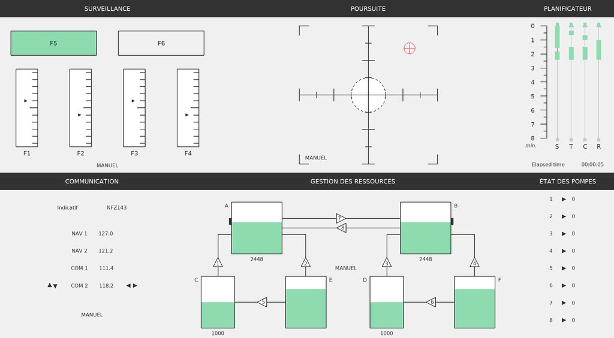

Almost thirty years have passed since the first iteration of the MATB implementation (Comstock & Arnegard, 1992), different requirements for up to date research are no longer satisfied.

OpenMATB aims to provide an open-source re-implementation of the multi-attribute task battery. It promotes three aspects: 1. tasks customization for full adaptation of the battery, 2. software extendability to easily add new features, 3. experiment replicability to provide significant results.

Those aspects are detailed in:

Cegarra, J., Valéry, B., Avril, E. et al. OpenMATB: A Multi-Attribute Task Battery promoting task customization, software extensibility and experiment replicability. *Behavioral Research Methods*, 52, 1980–1990 (2020). https://doi.org/10.3758/s13428-020-01364-w

Contact : julien.cegarra AT univ-jfc.fr; benoit.valery AT univ-jfc.fr

## Requirements

The last version requires Python 3.9 and only depends on the following third-part libraries:

- pyglet
- pyparallel
- rstr
- pylsl

The program is compatible with Windows, Mac and Linux systems. To run perfectly, the software requires only a personal computer and a joystick for the tracking task.

## Cross-platform installation

The first thing to do is to [install python 3.9](https://www.python.org/downloads/) on your computer.

To execute OpenMATB on most platforms, simply clone the current repository to a given local folder. Then, make sure you installed the correct python libraries with pip. The correct library versions are written in `requirements.txt`. You can use the `-r` flag of `pip` to install everything at once.

(In the commands below, replace `python` with `py`, under Windows)

```bash
python -m pip install -r requirements.txt
```

You can now launch OpenMATB by executing the `main.py` file with python 3.9.

```bash
python main.py
```

### Virtual environment

If you want to create a dedicated python installation (so various python projects won’t overlap), you might want to install a virtual environment in your local repository. To do so, follow the instructions detailed on this [related page](https://docs.python.org/3.9/tutorial/venv.html).

**Warning:** be sure to create the virtual environment into a directory named `.venv`. If you want to use an other name, make sure to change the `main.py` [shebang](https://docs.python.org/3.9/tutorial/appendix.html#tut-scripts) (`#! .venv/bin/python3.9`) that allows its direct execution with the distribution installed in the virtual environment.

Once the virtual environment is set, you must activate it to install the required dependencies into it:

- **Under Linux**: `source .venv/bin/activate`
- **Under Windows**: `.venv\Scripts\activate.bat` (see [this page](https://docs.python.org/3.9/tutorial/venv.html) for more information).

Now that your virtual environment is activated, just install the dependencies as you would do for a “global” python distribtion.

```bash
python -m pip install -r requirements.txt
```

Finally, you can simply execute the `main.py`. Two possibilities here :

1. You can activate the OpenMATB virtual environment and type `python main.py` in the shell;
2. Or you can execute `main.py` and let the shebang finds the virtual distribution for you. In that case, (a) no need to activate the virtual environment, (b) be sure that you made the `main.py` file executable.

### Use of compiled source (coming soon)

If you don’t mind not seeing all the source files, you might want to use compiled versions of the software. The good thing here is that you don’t have to install neither python nor its dependencies to make OpenMATB working.

- **For Linux**: COMING SOON
- **For Windows**: COMING SOON

## Basic example of OpenMATB usage

*More detailed instructions are available in the Tutorials (wiki) section below.*

When executed, the main file basically inspects the `config.ini` variables, that are `language`**, `screen_index`, `fullscreen`, `scenario_path` and `clock_speed`. The most important is the `scenario_path` variable because it defines what scenario textfile should be used for the sequencing and the setting of the protocol.

(**For now, french (fr_FR) and english (en_EN) locales are available, but feel free to [develop your own translation](https://github.com/juliencegarra/OpenMATB/wiki/Internationalization), it’s fast and easy.)

A scenario is a text file which specifies, for each module of the program (for instance the system monitoring task), all the events that it must execute, as well as their onset time. For instance, try this basic scenario, which starts the four main tasks of the MATB, and stop them after 2 minutes and a half. (Note how each command — `start` and `stop` in this example — is associated with an alias: for instance `sysmon` for the system monitoring task.)

*Content of `includes/scenarios/basic.txt`*:

```
0:00:00;sysmon;start
0:00:00;track;start
0:00:00;scheduling;start
0:00:00;resman;start
0:00:00;communications;start
0:02:30;sysmon;stop
0:02:30;track;stop
0:02:30;communications;stop
0:02:30;resman;stop
0:02:30;scheduling;stop
```

Through the scenario file, you can command the various tasks or modules, modify their own parameters, and trigger interesting events. The more you know about the scenario file syntax and modules options, the more you will be able to customize your OpenMATB scenario. See [this tutorial](https://github.com/juliencegarra/OpenMATB/wiki/How-to-build-a-scenario-file) for more information.

Once the scenario has ended, information about what happended is stored as comma-separated values (.csv) into the `sessions` directory. This log file contains all that is needed to understand what happened during the scenario and undertake performance calculations. It has the following form:

```
logtime,totaltime,scenario_time,type,module,address,value
13869.194646,0,0,input,keyboard,ENTER,release
13869.210557,0.018296,0,state,sysmon,"task_title, text",SURVEILLANCE
13869.210933,0.018296,0,state,sysmon,"automode, text",
13869.232539,0.018296,0,event,sysmon,self,start
13869.238017,0.058883,0.018296,state,track,"task_title, text",POURSUITE
13869.238209,0.058883,0.018296,state,track,"automode, text",
13869.24057,0.058883,0.018296,event,track,self,start
13869.240641,0.058883,0.018296,performance,track,cursor_in_target,1
13869.240664,0.058883,0.018296,performance,track,center_deviation,0.0
...
14307.553591,150.022335,150.008259,state,track,"reticle, cursor_relative","(-98.86763793277942, 149.15892483599305)"
14307.553667,150.022335,150.008259,state,track,"reticle, cursor_color","(241, 100, 100, 255)"
14307.566581,150.038228,150.022335,event,track,self,stop
14307.586672,150.054776,150.038228,event,communications,self,stop
14307.610734,150.071739,150.054776,event,resman,self,stop
14307.620835,150.088269,150.071739,event,scheduling,self,stop
14307.620911,150.088269,150.071739,manual,,,end
```

## Tutorials

For more information about how to use OpenMATB, please refers to [our wiki](https://github.com/juliencegarra/OpenMATB/wiki).

## Major changes

Since the first release of OpenMATB, there has been a lot of changes, the main one of which are listed below.

### Version 1.2

**New plugins/features:**

- Each scenario value is now finely controlled against a set of type verification methods. For instance, a `taskplacement` value must be a correct value (being in location_list = [‘fullscreen’, ‘topmid’, ‘topright’, ‘topleft’, ‘bottomleft’, ‘bottommid’, ‘bottomright’]), and so on, which greatly facilitates scenario debugging.
- Each scenario error is now logged into a `last_scenario_errors.log` file.
- The scenario does not need a final ending line anymore (e.g., `0:05:00;end`). Program now exits if there is no event to execute anymore and all the modules have been stopped.
- Added a `config.ini` file where to modify the main OpenMATB parameters, such as the scenario to use, the locale, the fullscreen mode…
- Switch from PySide/PyQt to the pyglet graphical library, which has the major advantage to be a pure python library.
- Can now exit OpenMATB with the Escape key + confirmation.
- OpenMATB can now be paused with the P key.
- The user can now define a global font into `config.ini`, given it is availale on his/her computer
- Areas of interest (AOI) of each task are now automatically logged at start, for further (oculometric) computations. AOIs can be displayed for debugging purpose, with the `highlight_aoi` parameter of the `config.ini` file.
- To comply with anonymity constraints, the `participantinfo` was removed and replace with a session ID, displayed at startup. This session ID (e.g., 52) is used as a suffix for session logging files.
- A particular scenario generator was added, so as to help conceiving scenario of progressive difficulty.
- Each task module now logs a serie of performance metrics as soon as their are available, to facilitate further calculations.